# Исследование объявлений о продаже квартир

## Предобработка данных

Выше с помощью метода info мы узнали, что у нас есть пропуски в данных в следующих столбцах:

- ceiling_height - пропуски заполним средним медианным значением
- locality_name - удалим пропуски
- balcony - вероятно пропуски допущены в квартирах без балконов. Заменим значения NaN на 0.
- floors_total - можно было бы предположить, что этажность дома пропущена в одноэтажных частных домах, но это не так, мы не можем восстановить пропущенные данные без отдельной базы данных, их доля очень мала, поэтому удалим строки.
- kitchen_area - возможно, что отсутствующие данные по кухням - это квартиры-студии. Проверим эту гипотезу.

### Заполнение пропусков и исправление ошибок в данных

```python
data['balcony'] = data['balcony'].fillna(0)   #Заменим значения NaN на 0.
data = data.dropna(subset=['floors_total', 'locality_name' ])    # удалим строки с пропущенными значениями в floors_total
# удалим строки с пропущенными значениями в locality_name
```

Для заполнения пропусков в living_area рассчитаем соотношения общей и жилой площади и возьмём из них среднее медианное значение. Используем его в качестве коэффициента к общей площади.

```python
cof_for_living = data['living_area'].median()/data['total_area'].median()
data['living_area'] = data['living_area'].fillna(data['total_area']*cof_for_living)
```

Изучим имеют ли квартиры-студии без отдельной кухни пропуск в столбце 'kitchen_area':

```python
print('Количество пропусков в столбце "kitchen_area":', data[data['kitchen_area'].isna()]['studio'].count())
print('Количество квартир-студий в датафрейме:', data[data['studio'] == True]['studio'].count())
print('Количество квартир-студий в датафрейме с пропуском в площади кухни:', data[(data['kitchen_area'].isna()) & (data['studio'] == True)]['studio'].count())
```

```
Количество пропусков в столбце "kitchen_area": 2222
Количество квартир-студий в датафрейме: 146
Количество квартир-студий в датафрейме с пропуском в площади кухни: 146
```

У всех студий действительно имеется пропуск. Заполним эти строки значением 0. Но останется ещё около 2000 строк с пропусками. Это не студии, значит кухни там должны быть. Нужен коэффициент, с помощью которого мы заполним пропуски. Не всегда работает правило, что чем больше площадь квартиры - тем больше кухня. Часто встречаются большие квартиры с маленькими кухнями. Поэтому более правильно будет считать соотношение кухонь к нежилой площади, т.е. total_area - living_area

```python
cof_for_kitchen = data['kitchen_area'].median()/(data['total_area'] - data['living_area']).median()

data['kitchen_area'] = data['kitchen_area'].fillna(((data['total_area'] - data['living_area']))*cof_for_kitchen)
```

```python
data[data['kitchen_area'].isna()]['kitchen_area'].count()    # убедимся, что не осталось пропусков
```

```
0
```

В столбце first_day_exposition изменим тип данных на datetime, чтобы в дальнейшем можно было в дальнейшем работать с датами

```python
data['first_day_exposition'] = pd.to_datetime(data['first_day_exposition'], format='%Y-%m-%dT%H:%M:%S')
```

```python
# код ревьюера
# 1. Ищем соотношения
#cof_for_living = data['living_area'].median()/data['total_area'].median()


# 2. Заполняем отношением общей площади к найденному коэффициенту - соотношению
#data['living_area'] = data['living_area'].fillna(data['total_area']*cof_for_living)
```

```python
data[['last_price', 'total_area', 'living_area', 'rooms', 'ceiling_height']].describe()
```

|  | last_price | total_area | living_area | rooms | ceiling_height |
| --- | --- | --- | --- | --- | --- |
| count | 2.356500e+04 | 23565.000000 | 23565.000000 | 23565.000000 | 14481.000000 |
| mean | 6.540058e+06 | 60.322824 | 34.621108 | 2.070656 | 2.771283 |
| std | 1.091093e+07 | 35.657060 | 22.399827 | 1.078591 | 1.261983 |
| min | 1.219000e+04 | 12.000000 | 2.000000 | 0.000000 | 1.000000 |
| 25% | 3.400000e+06 | 40.000000 | 19.000000 | 1.000000 | 2.510000 |
| 50% | 4.646000e+06 | 52.000000 | 30.000000 | 2.000000 | 2.650000 |
| 75% | 6.790000e+06 | 69.700000 | 42.115385 | 3.000000 | 2.800000 |
| max | 7.630000e+08 | 900.000000 | 409.700000 | 19.000000 | 100.000000 |

Проверим колонки, где выше мы увидели длинные хвосты на предмет аномальных значений. Колонка, содержащая общую площадь имеет максимальное значение 900 метров, что вполне реально, если в нашем датасете присутствует в т.ч. и элитная недвижимость. Тоже самое можно сказать про living_area и rooms. А вот ceiling_height с максимальным значением 100 нам говорит о каких-то ошибках. Посмотрим поподробнее. Отфильтруем значения выше логического предела в 6 метров.

```python
data[data['ceiling_height'] > 6]['ceiling_height'].value_counts()
```

```
27.0     8
25.0     7
8.0      3
32.0     2
14.0     1
20.0     1
24.0     1
27.5     1
10.3     1
8.3      1
22.6     1
26.0     1
100.0    1
Name: ceiling_height, dtype: int64
```

Таких строк мало. Предположим, что квартиры до 6 метров - это двухуровневые квартиры. Также предположим, что такие значения, как 27.0, 25.0 имеют ошибку в знаке. Перенесём его на один знак влево. Напишем для этого функцию ceiling_correction

```python
def ceiling_correction(num):
    ceiling_height = float(num)
    if ceiling_height >= 20:
        return ceiling_height/10
    return ceiling_height
```

```python
data['ceiling_height'] = data['ceiling_height'].apply(ceiling_correction)
```

Для заполнения пропусков в ceiling_height используем медианное значение из всех значений данного столбца.

```python
data['ceiling_height'] = data['ceiling_height'].fillna(data['ceiling_height'].median())
```

Создадим функцию, убирающую из названий населённых пунктов указание их типа - посёлка, деревни. Так как имеется дублирование одних и тех же названий.

```python
def locality_name_corr(name):
    split_name = name.split(' ')
    del_list = ['посёлок', 'поселок', 'село', 'деревня', 'городского', 'городской', 'типа', 'коттеджный']
    result = [i for i in split_name if i not in del_list]
    return ' '.join(result)
```

```python
data['locality_name'] = data['locality_name'].apply(locality_name_corr)   # избавимся от неявных дубликатов
```

### Добавим в таблицу новые столбцы

```python
data['price_per_metr'] = (data['last_price']/data['total_area']).round(decimals=2)       # цена за метр
data['day_of_exposition'] = data['first_day_exposition'].dt.weekday                      # день публикации
data['month_of_exposition'] = data['first_day_exposition'].dt.month                      # месяц публикации
data['year_of_exposition'] = data['first_day_exposition'].dt.year                        # год публикации
data['cityCenters_km'] = (data['cityCenters_nearest']/1000).round()                      # расстояние до центра города в км
```

"Для добавления типа этажа напишем функцию floor_type, которая вернёт значения "первый, последний или другой"

```python
def floor_type(num1, num2):

    if num1 == 1:
        return 'первый'
    if num1 == num2:
        return 'последний'
    return 'другой'
```

```python
data['floor_type'] = data.apply(lambda x: floor_type(x['floor'], x['floors_total']), axis=1)  # добавляем тип этажа. Функция принимает два значения - этаж и этажность дома.
```

```python
data.head(5)    # проверим несколько строк изменённого датасета
```

|  | total_images | last_price | total_area | first_day_exposition | rooms | ceiling_height | floors_total | living_area | floor | is_apartment | ... | parks_nearest | ponds_around3000 | ponds_nearest | days_exposition | price_per_metr | day_of_exposition | month_of_exposition | year_of_exposition | cityCenters_km | floor_type |
| --- | --- | --- | --- | --- | --- | --- | --- | --- | --- | --- | --- | --- | --- | --- | --- | --- | --- | --- | --- | --- | --- |
| 0 | 20 | 13000000.0 | 108.0 | 2019-03-07 | 3 | 2.70 | 16.0 | 51.000000 | 8 | NaN | ... | 482.0 | 2.0 | 755.0 | NaN | 120370.37 | 3 | 3 | 2019 | 16.0 | другой |
| 1 | 7 | 3350000.0 | 40.4 | 2018-12-04 | 1 | 2.65 | 11.0 | 18.600000 | 1 | NaN | ... | NaN | 0.0 | NaN | 81.0 | 82920.79 | 1 | 12 | 2018 | 19.0 | первый |
| 2 | 10 | 5196000.0 | 56.0 | 2015-08-20 | 2 | 2.65 | 5.0 | 34.300000 | 4 | NaN | ... | 90.0 | 2.0 | 574.0 | 558.0 | 92785.71 | 3 | 8 | 2015 | 14.0 | другой |
| 3 | 0 | 64900000.0 | 159.0 | 2015-07-24 | 3 | 2.65 | 14.0 | 91.730769 | 9 | NaN | ... | 84.0 | 3.0 | 234.0 | 424.0 | 408176.10 | 4 | 7 | 2015 | 7.0 | другой |
| 4 | 2 | 10000000.0 | 100.0 | 2018-06-19 | 2 | 3.03 | 14.0 | 32.000000 | 13 | NaN | ... | 112.0 | 1.0 | 48.0 | 121.0 | 100000.00 | 1 | 6 | 2018 | 8.0 | другой |

5 rows × 28 columns

## Исследовательский анализ данных

### Изучение различных параметров объектов

Изучим перечисленные ниже параметры объектов и построим отдельные гистограммы для каждого из этих параметров. Список параметров:

- общая площадь;
- жилая площадь;
- площадь кухни;
- цена объекта;
- количество комнат;
- высота потолков;
- тип этажа квартиры («первый», «последний», «другой»);
- общее количество этажей в доме;
- расстояние до центра города в метрах;
- расстояние до ближайшего парка

```python
def upper_bound(column):
    Q1 = data[column].quantile(0.25)
    Q3 = data[column].quantile(0.75)
    IQR = Q3 - Q1
    upper = Q3 + 1.5 * IQR
    return upper
```

Для удобства создадим функцию, принимающую название колонки, и возвращающую верхний предел значений для нашего анализа, отсекающий возможные выбросы, рассчитаный, как межвантильный размах, умноженный на 1,5.

Сначала проверим данные общей площади жилья:

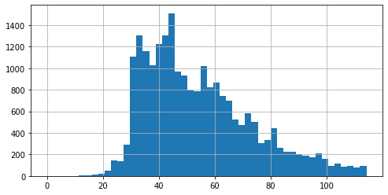

```python
data['total_area'].hist(bins=50, range=(0, upper_bound('total_area')), figsize=(8,4))
```

```python
data['total_area'].describe()
```

```
count    23565.000000
mean        60.322824
std         35.657060
min         12.000000
25%         40.000000
50%         52.000000
75%         69.700000
max        900.000000
Name: total_area, dtype: float64
```

Мы видим, что большая часть продаваемых квартир имеют площадь от 30 до 60 метров с пиком от 40 до 45 м. Квартиры свыше 100 метров встречаются сильно реже. Медиана - 52 метра. Самая маленькая квартира - 12 м., самая большая - 900 м.

```python
data['living_area'].describe()
```

```
count    23565.000000
mean        34.621108
std         22.399827
min          2.000000
25%         19.000000
50%         30.000000
75%         42.115385
max        409.700000
Name: living_area, dtype: float64
```

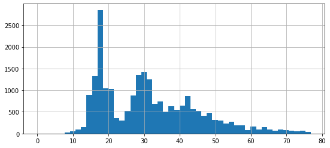

```python
data['living_area'].hist(bins=50, range=(0, upper_bound('living_area')), figsize=(9,4))
```

Жилая площадь. Типовые квартиры от 19 до 42 метров. Видим два выделяющихся пика - до 18 метров и 30 метров. Они говорят нам, что большая часть квартир - это 1 и 2ух комнатные. Проверим этот факт в дальнейшем. Медиана 30 метров.

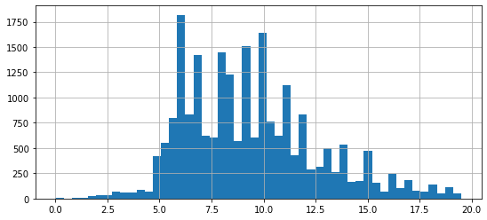

```python
data['kitchen_area'].hist(bins=50, range=(0, upper_bound('kitchen_area')), figsize=(9,4))
```

```python
data['kitchen_area'].describe()
```

```
count    23565.000000
mean        10.473096
std          6.062789
min          0.000000
25%          7.000000
50%          9.000000
75%         12.000000
max        112.000000
Name: kitchen_area, dtype: float64
```

```
Площадь кухни. На гистограмме много пиков - самые высокие на 6 и 10 метров. Большинство типовых квартир имеют кухни от 7 до 12 метров. Медиана - 9 метров.
```

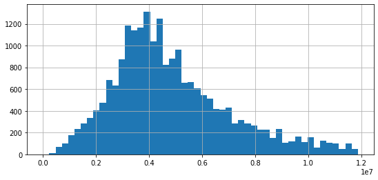

```python
data['last_price'].hist(bins=50, range=(0, upper_bound('last_price')), figsize=(9,4))
```

```python
data['last_price'].describe()
```

```
count    2.356500e+04
mean     6.540058e+06
std      1.091093e+07
min      1.219000e+04
25%      3.400000e+06
50%      4.646000e+06
75%      6.790000e+06
max      7.630000e+08
Name: last_price, dtype: float64
```

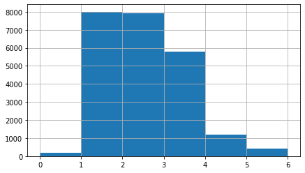

```python
data['rooms'].hist(bins=6, range=(0, upper_bound('rooms')), figsize=(7,4))
```

```python
data['rooms'].describe()
```

```
count    23565.000000
mean         2.070656
std          1.078591
min          0.000000
25%          1.000000
50%          2.000000
75%          3.000000
max         19.000000
Name: rooms, dtype: float64
```

Колличество комнат. Есть небольшая доля квартир, где указано 0 комнат. Если это не техническая ошибка, то так могли указать квартиры-студии. Чтобы проверить эти гипотезу, посмотрим на среднюю площадь этих квартир.

```python
data[data['rooms'] == 0]['total_area'].mean()
```

```
29.321701030927834
```

29 это вполне реалистичная площадь для студии. Даже с учётом выбросов, которые влияют на среднюю. Взглянем ещё на распределение на гистаграмме.

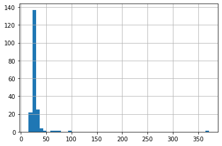

```python
data[data['rooms'] == 0]['total_area'].hist(bins=50)
```

Действительно почти все эти квартиры имеют маленькую площадь, похожую для квартир-студий. Остальные квартиры - вероятные технические ошибки. В таком случае можно считать эти квартиры 1-комнатными, что сделает их самыми продаваемыми. Немного меньше продаётся 2ух комнатных квартир. Далее по уменьшению колличества идут 3ёхкомнатные. Медиана 2.

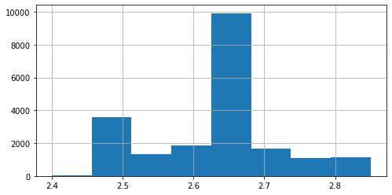

```python
data['ceiling_height'].hist(bins=8, range=(2.4, upper_bound('ceiling_height')), figsize=(8,4))
```

```python
data['ceiling_height'].describe()
```

```
count    23565.000000
mean         2.698746
std          0.253630
min          1.000000
25%          2.600000
50%          2.650000
75%          2.700000
max         14.000000
Name: ceiling_height, dtype: float64
```

Высота потолков. Вручную срезали на гистограмме аномально низкие значения. Большая часть значений находится в интервале 2,6 - 2,7 метров. Медиана 2,65

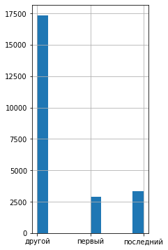

```python
data['floor_type'].hist(figsize=(3,6))
```

Тип этажа. Подавляющая часть квартир распололожена не на первом и не на последнем этажах. На последнем этаже квартир продавалось чуть больше, чем на первом.

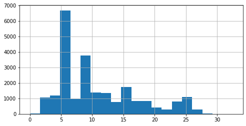

```python
data['floors_total'].hist(bins=20, range=(0, upper_bound('floors_total')), figsize=(8,4))
```

```python
data['floors_total'].describe()
```

```
count    23565.000000
mean        10.675875
std          6.594823
min          1.000000
25%          5.000000
50%          9.000000
75%         16.000000
max         60.000000
Name: floors_total, dtype: float64
```

Колличество этажей в доме. До сих пор большая часть продаваемых квартир расположена в 5тиэтажных домах. Почти в два раза меньше в 9тиэтажных. И ещё в два раза меньше в 16тиэтажных. Можно сделать вывод, что это 3 самых распространённых типа домов в Ленинградской области и Санкт-Петербурге. Медиана 9.

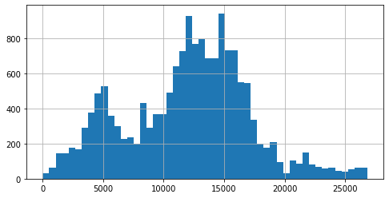

```python
data['cityCenters_nearest'].hist(bins=50, range=(0, upper_bound('cityCenters_nearest')), figsize=(8,4))
```

```python
data['cityCenters_nearest'].describe()
```

```
count    18064.000000
mean     14192.656056
std       8613.348153
min        181.000000
25%       9238.000000
50%      13096.500000
75%      16285.000000
max      65968.000000
Name: cityCenters_nearest, dtype: float64
```

Удалённость от центра города. Большинство квартир удалены на расстоянии от 9 до 16 км. Медиана 13 км.

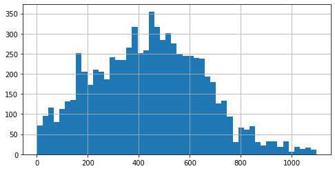

```python
data['parks_nearest'].hist(bins=50, range=(0, upper_bound('parks_nearest')), figsize=(8,4))
```

```python
data['parks_nearest'].describe()
```

```
count    8030.000000
mean      490.580448
std       341.572956
min         1.000000
25%       288.000000
50%       455.000000
75%       612.000000
max      3190.000000
Name: parks_nearest, dtype: float64
```

Удаленность от парка. Большинство квартир удалены на расстоянии от 288 до 600 м. Медиана 455 метра.

```python
new_df_info = data.shape
print('В датафрейме осталось', (new_df_info[0]/df_info[0]*100), '% от изначальных данных' )
```

```
В датафрейме осталось 99.4345752985358 % от изначальных данных
```

Мы потеряли всего 0,5% от объёма изначальных данных. Отличный результат.

### Как быстро продавались квартиры

```python
data['days_exposition'].describe()
```

```
count    20394.000000
mean       180.741395
std        219.732782
min          1.000000
25%         45.000000
50%         95.000000
75%        231.000000
max       1580.000000
Name: days_exposition, dtype: float64
```

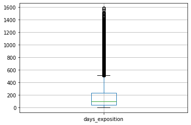

```python
data.boxplot(column='days_exposition')
```

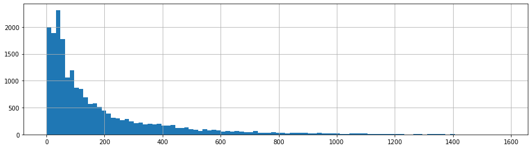

```python
data['days_exposition'].hist(bins=100, figsize=(15,4))
```

Самый быстрый срок продажи - 1 день. Половина всех обьявлений снимаются в интервале 45 - 232 дня. Но есть и обьявления, которые держатся гораздо дольше. 25% всех обьявлений публикуются более 232 дней. Максимальный срок 1580 дней. Причиной может быть завышенная цена или непонятный злой умысел человека, разместившего обьявление. Медиана 95 дней. Видим в начале гистограммы несколько пиков, нужно посмотреть на них поближе, выведя новую гистаграмму, настроив range

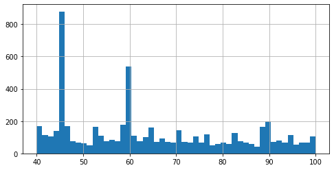

```python
data['days_exposition'].hist(bins=50, figsize=(8,4), range=(40,100))
```

Много обьявлений снимаются на 45ый, 60ый и 90ый дни. Все пики кратны 15ти, возможно это связано с системой на сайте, которая автоматически снимает обьявление при достижении определённого срока. Быстрой продажей можно считать срок до 45 дней. Аномально долгим срок свыше 232 дней.

### Факторы, которые больше всего влияют на общую (полную) стоимость объекта

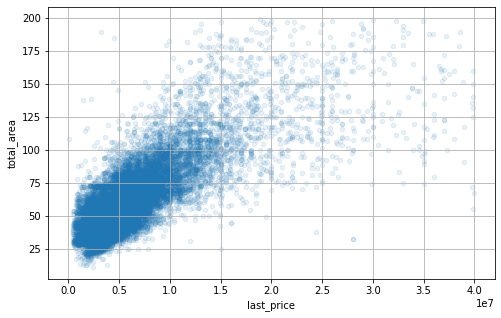

```python
data.query('last_price<4e7 and total_area<200').plot(x='last_price', y='total_area', grid=True, kind='scatter', figsize=(8,5), alpha=0.1)
```

Влияние общей площади на стоимость жилья прямо пропорционально. Стоимость жилья растёт при росте общей площади.

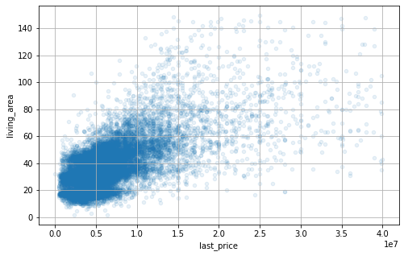

```python
data.query('last_price<4e7 and living_area<150').plot(x='last_price', y='living_area', grid=True, kind='scatter', figsize=(8,5), alpha=0.1)
```

Жилая площадь влияет на стоимость. При росте жилой площади, растёт и цена

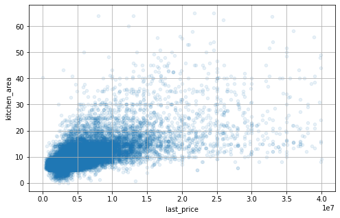

```python
data.query('last_price<4e7 and kitchen_area<70').plot(x='last_price', y='kitchen_area', grid=True, kind='scatter', figsize=(8,5), alpha=0.1)
```

Цена не сильно зависит от площади кухни

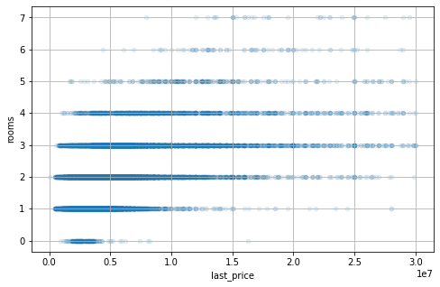

```python
data.query('last_price<3e7 and rooms<8').plot(x='last_price', y='rooms', grid=True, kind='scatter', figsize=(8,5), alpha=0.1)
```

С ростом колличества комнат растёт максимальная цена. Минимальные цены до 3ёх комнат не сильно различаются.

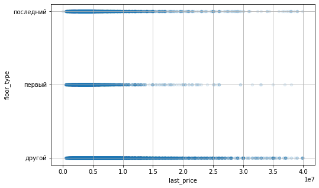

```python
data.query('last_price<4e7').plot(x='last_price', y='floor_type', grid=True, kind='scatter', figsize=(8,5), alpha=0.1)
```

Цена растёт в следующем порядке: первый этаж, последний этаж, другие этажи.

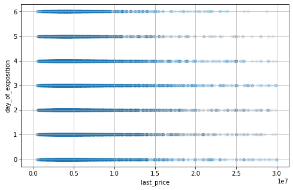

```python
data.query('last_price<3e7').plot(x='last_price', y='day_of_exposition', grid=True, kind='scatter', figsize=(8,5), alpha=0.1)
```

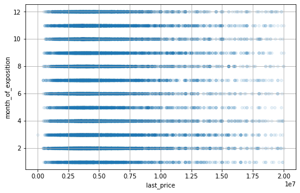

```python
data.query('last_price<2e7').plot(x='last_price', y='month_of_exposition', grid=True, kind='scatter', figsize=(8,5), alpha=0.1)
```

Месяц не влияет на стоимость жилья

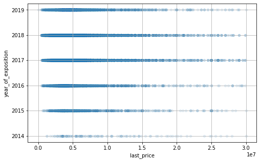

```python
data.query('last_price<3e7').plot(x='last_price', y='year_of_exposition', grid=True, kind='scatter', figsize=(8,5), alpha=0.1)
```

Цена меняется в зависимости от года.

Больше всего на цену жилья влияет её общая площадь, жилая площадь, этаж (особенно первый), колличество комнат, а также год. В меньшей степени влияет площадь кухни, и день публикации обьявления. Месяц публикации обьявления совсем не влияет на цену.

### Cредняя цена одного квадратного метра в 10 населённых пунктах с наибольшим числом объявлений

```python
top_per_metr = pd.pivot_table(data, index='locality_name', values=['rooms', 'price_per_metr'], aggfunc={'rooms':'count', 'price_per_metr': 'mean'})
top_per_metr = top_per_metr.sort_values(by='rooms', ascending=False)
top_per_metr['price_per_metr'][0:10]
```

```
locality_name
Санкт-Петербург    114868.877339
Мурино              86041.116024
Кудрово             95260.846128
Шушары              78551.344647
Всеволожск          68654.473970
Пушкин             103125.819377
Колпино             75424.579112
Парголово           90175.913089
Гатчина             68746.146515
Выборг              58141.909325
Name: price_per_metr, dtype: float64
```

Самая высокая цена квадратного метра в Санкт-Петербурге и Пушкино. Самая низкая цена квадратного метра в Выборге.

### Средняя стоимость квартир в Санкт-Петербург на разном удалении от центра

```python
res = data.query('locality_name == "Санкт-Петербург"').pivot_table(index='cityCenters_km', values='last_price').reset_index().round()
res.columns = ['Расстояние от центра (км.)', 'Средняя цена квартиры']
res
```

|  | Расстояние от центра (км.) | Средняя цена квартиры |
| --- | --- | --- |
| 0 | 0.0 | 31449116.0 |
| 1 | 1.0 | 21206721.0 |
| 2 | 2.0 | 17788320.0 |
| 3 | 3.0 | 11137395.0 |
| 4 | 4.0 | 13304280.0 |
| 5 | 5.0 | 14455996.0 |
| 6 | 6.0 | 15338418.0 |
| 7 | 7.0 | 14775153.0 |
| 8 | 8.0 | 9949111.0 |
| 9 | 9.0 | 6956583.0 |
| 10 | 10.0 | 6500434.0 |
| 11 | 11.0 | 6228108.0 |
| 12 | 12.0 | 5834619.0 |
| 13 | 13.0 | 6077643.0 |
| 14 | 14.0 | 5625173.0 |
| 15 | 15.0 | 5876323.0 |
| 16 | 16.0 | 5373131.0 |
| 17 | 17.0 | 5299496.0 |
| 18 | 18.0 | 5091331.0 |
| 19 | 19.0 | 5051410.0 |
| 20 | 20.0 | 5951465.0 |
| 21 | 21.0 | 5493469.0 |
| 22 | 22.0 | 5415524.0 |
| 23 | 23.0 | 4985376.0 |
| 24 | 24.0 | 3854430.0 |
| 25 | 25.0 | 4052840.0 |
| 26 | 26.0 | 4014287.0 |
| 27 | 27.0 | 8300000.0 |
| 28 | 28.0 | 5026429.0 |
| 29 | 29.0 | 4236667.0 |

Мы видим, как стоимость квартиры понижается при удалении из центра на каждый километр. Затем корректируется вверх в районе 5-7 километров от центра, и затем снова снижается до 10го километра. После 10го километра цена понижается очень слабо. Можно сказать, что расстояние от центра сильно влияет на цену в интервале от 0 до 10го километра, а затем почти не оказывает влияния. Есть всплеск цены после 26 километров. Возможно на таком расстоянии находятся какие-то элитные кварталы.

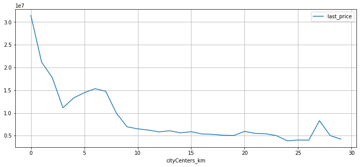

```python
data.query('locality_name == "Санкт-Петербург"').pivot_table(index='cityCenters_km', values='last_price').plot(grid=True, figsize=(12,5))
```

Но проверим ещё одну гипотезу. Возможно в центре и на окраине города средние квартиры имеют сильно разную площадь, поэтому и цена разная. Возможно, что расстояние от центра иначе влияет на цену квадратного метра. Построим аналогичный график, но уже по средней цене квадратного метра на каждый километр.

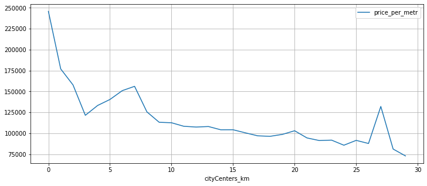

```python
data.query('locality_name == "Санкт-Петербург"').pivot_table(index='cityCenters_km', values='price_per_metr').plot(grid=True, figsize=(12,5))
```

График полностью подтверждает предыдущие выводы. Цена метра ведёт себя также, как и средняя цена квартиры. Чем дальше от центра, тем дешевле, с двумя исключениями после 5го и 26го км.

## Вывод

1. - На этапе предобработки данных были проверены данные, найдены и исправленны ошибки, изменён тип данных в столбце first_day_exposition.
- Были удалены пропуски в столбце floors_total и locality_name. Исправлены неявные дубли в столбце locality_name с названиями населённых пунктов.
1. Добавлены новые столбцы: цена за метр, день публикации, месяц публикации, год публикации, тип этажа квартиры, расстояние до центра города в км
2. Анализ данных может показать нам типовую квартиру:

   ```
    - Площадь 30-60 кв. метров;
    - Жилая площадь от 19 до 42 метров;
    - Площадь кухни от 7 до 12 метров;
    - Цена от 3,4 млн до 6,8 млн;
    - Колличество комнат от 1 до 3;
    - Высота потолков от 2,6 до 2,7 м.;
    - Расположенна не на первом и не на последнем этажах;
    - Расположена в 5 или 9-тиэтажном домах;
    - Удалена от центра на расстоянии от 9 до 16 км;
    - Удалена от ближайшего парка на расстоянии от 288 до 600 м.
   ```

3. Были проанализированы сроки продаж квартиры.

4. Были проанализированы факторы, которые влияют на цену объекта.

   ```
    - Больше всего на цену жилья влияет её общая площадь, жилая площадь, этаж (особенно первый), колличество комнат, а также год.
    - В меньшей степени влияет площадь кухни, и день публикации обьявления.
    - Месяц публикации обьявления совсем не влияет на цену.
   ```

5. Была посчитана средняя цена квадратного метра в 10 населённых пунктах с наибольшим числом обьявлений.

   ```
    - Самая высокая цена квадратного метра в Санкт-Петербурге (115 тыс.) и Пушкино (103 тыс).
    - Самая низкая цена квадратного метра в Выборге (58 тыс).
   ```

6. Было определено, как меняется цена в Санкт-Петербурге в зависимости от удаления от центра.

   ```
    - Стоимость квартиры понижается при удалении из центра на каждый километр.
    - Затем корректируется вверх в районе 5-7 километров от центра, и затем снова снижается до 10го километра.
    - После 10го километра цена понижается очень слабо.
    - Расстояние от центра сильно влияет на цену в интервале от 0 до 10го километра, а затем слабо оказывает влияние.
   ```